# R

Author: Patrick Weatherford

Last modified: 15 September 2021

### BASICS

#### Assign value(s) to variables

```r
nl <- "\n"

num_value <- 100

str_value <- "Hello world!"

multi_val <- 1:3

global_var <<- 3  # global variable

3 -> num_three  # if desired, assignment operator can be reversed
```

#### Data Types

```r
numeric_type <- 10.5

integer_type <- 1000L  # 'L' declares this as an integer

complex_type <- 9i + 3  # 'i' is the imaginary part

character_type <- "this is a string"

logical_type <- FALSE

date_type <- Sys.date()

datetime_type <- Sys.time()
```

#### Converting Data Types

```r
x <- 1L  # integer
y <- 2  # numeric

as.numeric(x)

as.integer(y)

as.complex(y)

as.Date("2021-03-15")

strptime("2021-03-15 13:25", format="%Y-%m-%d %H:%M")
```

#### Arithmetic Operators

```r
# addition
10+5

# subtraction
10-5

# multiply
10*5

# divide
10/5

# modulus (remainder from division)
7%%2

# exponent
2^3

# integer division
10%/%5

# square root
sqrt(144)

# absolute value
abs(-5)

# round
round(144.123456789, 4)

# ceiling
ceiling(144.123456789)

# floor
floor(144.123456789)

#
```

#### Logical/Comparison Operators

> The & and | operator will always evaluate ALL elements. That is, if you type x & y, R will always try to work out what x and y are. There are some cases where this is inefficient. For example, if x is FALSE, then x & y will always be FALSE, regardless of the value of y. Thus, you can save a little processing time by not calculating it. The && and || operators takes advantage of this trick, and doesn’t bother to calculate y if it doesn’t make a difference to the overall result.

```r
# & - Element-wise AND
1==2 & 2==2  # all elements evaluated.

# | - Element-wise OR
1==2 | 2==2  # all elements evaluated.

# && - Logical AND
# For below evaluation, because the first element is FALSE the entire
# expression will be FALSE. If using && this would mean that the other elements
# would NOT be evaluated. This would make the code more efficient. This makes &&
# useful in if,then,else statements and other control-flow processes.
1==2 && 2==2

# || - Logical OR
# For below evaluation, because the first element is TRUE the entire
# expression will be TRUE. If using || this would mean that the other elements
# would NOT be evaluated. This would make the code more efficient. This makes ||
# useful in if,then,else statements and other control-flow processes.
1==2 || 2==2

# == - Evaluate if equal
1==1

# != - Evaluate if not equal
1!=2

# > - Greater than
2 > 1

# >= - Greater than or equal to
2 >= 2

# < - Less than
2 < 1

# <= - Less than or equal to
2 <= 2

# %in% - element in vector
2 %in% c(1,2,3)
```

#### Simple Analysis

```r
start_vect <- c(15,30,70,5,100,20,25)

min(start_vect)
max(start_vect)
mean(start_vect)
median(start_vect)

# summary function outputs min, 1st qu., median, mean, 3rd qu., max
summary(start_vect)

# mean of start vector where values are less than 25
avg_less_than_25 <- mean(start_vect[start_vect < 25])

# total numbers less than 25
num_less_than_25 <- length(start_vect[start_vect < 25])
```

```
Minimum value: 5
```

```
Maximum value: 100
```

```
Mean: 37.85714
```

```
Median:  25
```

```
Summary:
```

```
   Min. 1st Qu.  Median    Mean 3rd Qu.    Max.
   5.00   17.50   25.00   37.86   50.00  100.00
```

```
Mean of values less than 25: 13.33333
```

```
Total numbers less than 25: 3
```

#### Date/Time Formatting

Date Formatting

- Sys.Date(): current date
- %Y %y: 4-digit year | 2-digit year
- %m: 2-digit month
- %d: 2-digit day of month
- %A %a: weekday (full name) | weekday (abbreviated)
- %B %b,%h: month (full name) | month (abbreviated)
- %j: day of the year
- %U: week number of year (Sunday first)
- %W: week number of year (Monday first)
- %w: weekday number 0-6 (Sunday 0)
- %u: weekday number 1-7 (Monday 1)
- %x: date, locale-specific (%y/%m/%d)
- %D: date formatted as (mm/dd/yy)
- %C: Century

Time Formatting

- Sys.time(): current datetime
- %c: datetime, locale-specific
- %H: hour as decimal (01-23)
- %I: hour as decimal (01-12)
- %M: minute as decimal (00-59)
- %p: AM/PM indicator, locale-specific
- %r: 12-hour clock time
- %R: hour:minute - equivalent to %H:%M
- %S: second as integer (00-61)
- %T: hour:minute:second - equivalent to %H:%M:%S
- %X: time, locale-specific
- %Z: timezone (abbreviated)
- %z: offset minutes/hours from UTC

```r
nl="\n"

date <- Sys.Date()
datetime <- Sys.time()

am_time <- format(datetime, "%m/%d/%y %I:%M %p (%Z) UTC%z")  # AM/PM 12-hour time formatted
week_num <- format(datetime, "%U")  # week number (Sunday first)
weekday_name <- format(date, "%A")  # abbreviated weekday
weekday_num <- format(date, "%w")  # weekday number 1-7 (Monday=1)
day_of_year <- format(date, "%j")

message(
  "sys date: ", date, nl
  , "sys datetime: ", datetime, nl
  , "datetime 12hr: ", am_time, nl
  , "week: ", week_num, nl
  , "weekday: ", weekday_name, " (", weekday_num, ")", nl
  , "day of year: ", day_of_year
)
```

```
sys date: 2021-09-15
sys datetime: 2021-09-15 12:27:19
datetime 12hr: 09/15/21 12:27 PM (CDT) UTC-0500
week: 37
weekday: Wednesday (3)
day of year: 258
```

### BUILT-IN FUNCTIONS

#### **nchar()** - Character Length

```r
#Character length of string

nchar("pneumonoultramicroscopicsilicovolcanoconiosis")
```

```
[1] 45
```

#### **length()** - Number of Elements

```r
# number of elements in a vector
length(c("abc","345if","g"))
```

```
[1] 3
```

#### **c()** - Create a Vector

```r
c(1,4,3,3,3)
```

```
[1] 1 4 3 3 3
```

#### **print()** - Output Expression to Vector

> Compared to many other programming languages, you do not have to use a function to print/output variables in R. You can just type the name of the variable. However, when your code is inside an R expression (for example inside curly braces {}, use the print() function if you want to output the result.

> One caveat of print() in R is that it cannot concatenate values together. This however is usually accomplished using a combination of print() AND paste()

```r
print("hello")

for (x in 1:3) {
  print(x)
}

# Using combination of print() & paste()
print(paste0("Print", " concat'd", " values"))
```

```
[1] "hello"
```

```
[1] 1
[1] 2
[1] 3
```

```
[1] "Print concat'd values"
```

#### **paste()** - Concat Into Single-Element Vector

```r
# Paste() separator governed by sep= parameter.
paste("this is","paste text", sep="||")

# Past0() has no separator
paste0("text with no"," seperator")
```

```
[1] "this is||paste text"
```

```
[1] "text with no seperator"
```

#### **cat()** - Concat & Output to Console

> Less process intensive than print but does not output result into a vector like print.

```r
#concatenates and outputs
cat("f dk kd", "asdf", c(1,2,3), sep="\n")
```

```
f dk kd
asdf
1
2
3
```

#### **message()** - Concat & Output Message

```r
#concatenate and output message. No separator parameter.
var1 <- "YO!"
message(var1," This is", " a message!")
```

```
YO! This is a message!
```

#### **head()** - First [n] Rows

> When working with a data frame use this function to bring back a limited amount of rows.

```r
data_frame <- data.frame(
  id = c(1,2,3,4)
  , name = c("Bob","Sue","Frank","Betty")
  , age = c(50,44,31,35)
)

head(data_frame, 3)  # get first 2 rows of the data frame
```

```
  id  name age
1  1   Bob  50
2  2   Sue  44
3  3 Frank  31
```

#### **nrow()** - Row Count

```r
data_frame <- data.frame(
  id = c(1,2,3,4)
  , name = c("Bob","Sue","Frank","Betty")
  , age = c(50,44,31,35)
)

nrow(data_frame)
```

```
[1] 4
```

#### **ncol()** - Column Count

```r
data_frame <- data.frame(
  id = c(1,2,3,4)
  , name = c("Bob","Sue","Frank","Betty")
  , age = c(50,44,31,35)
)

ncol(data_frame)
```

```
[1] 3
```

#### **names()** - Get/Set Name

```r
data_frame <- data.frame(
  id = c(1,2,3,4)
  , name = c("Bob","Sue","Frank","Betty")
  , age = c(50,44,31,35)
)

# output current col names
col_names <- names(data_frame)
col_names

# change "name" column to "first_name" and output
names(data_frame)[2] <- "first_name"
new_col_names <- names(data_frame)
new_col_names
```

```
[1] "id"   "name" "age"
```

```
[1] "id"         "first_name" "age"
```

#### **str()** - Display R Object Structure

```r
data_frame <- data.frame(
  id = c(1,2,3,4)
  , name = c("Bob","Sue","Frank","Betty")
  , age = c(50,44,31,35)
)

vector1 <- c(1,2,5,7)
str1 <- ("yo")

# If object is data-frame, R will retrieve:
# - Number of observations (rows)
# - Number of variables (columns)
# - Column names, their data type, and first few observation values
str(data_frame)

str(vector1)

str(str1)
```

```
'data.frame':   4 obs. of  3 variables:
 $ id  : num  1 2 3 4
 $ name: chr  "Bob" "Sue" "Frank" "Betty"
 $ age : num  50 44 31 35
```

```
 num [1:4] 1 2 5 7
```

```
 chr "yo"
```

#### **table()** - Frequency Count

```r
data(iris)

iris_df <- iris

table(iris$Species)
```

```
    setosa versicolor  virginica
        50         50         50
```

#### **date.frame()** - Create Data Frame

```r
# Create a data frame
data_frame <- data.frame (
  Training = c("Strength", "Stamina", "Other"),
  Pulse = c(100, 150, 120),
  Duration = c(60, 30, 45)
)

data_frame
```

```
  Training Pulse Duration
1 Strength   100       60
2  Stamina   150       30
3    Other   120       45
```

#### **format()** - Format Object

```r
nl="\n"

date <- Sys.Date()
datetime <- Sys.time()


year <- format(date, format="%Y")  # year
hour24 <- format(datetime, format="%H")  # hour (0-23)

message(
  "datetime: ", datetime, nl, nl
  , "year: ", year, nl
  , "24hr: ", hour24
)
```

```
datetime: 2021-09-15 12:27:19

year: 2021
24hr: 12
```

#### **rbind()** - Union Data Frames

```r
data_frame1 <- data.frame(
  Item = c("TV","Desk")
  , Cost = c(500,300)
)

data_frame2 <- data.frame(
  Item = c("Chair")
  , Cost = c(200)
)

rbind_data_frame <- rbind(data_frame1, data_frame2)
rbind_data_frame
```

data_frame1

| Item | Cost |
| --- | --- |
| TV | 500 |
| Desk | 300 |

data_frame2

| Item | Cost |
| --- | --- |
| Chair | 200 |

rbind_data_frame

| Item | Cost |
| --- | --- |
| TV | 500 |
| Desk | 300 |
| Chair | 200 |

#### **merge()** - Join Data Frames

```r
left_table <- data.frame(
  ID = c("e100","e101","e102","e103")
  , COLOR = c("Red","Green","Red","Blue")
)

right_table <- data.frame(
  ID = c("e100","e102","e103","e104")
  , COST = c(100,250,15,75)
)

# Inner Join
inner_join <- merge(left_table, right_table, by.x = "ID", by.y = "ID")

# Left Join
left_join <- merge(left_table, right_table, by.x = "ID", by.y = "ID", all.x = TRUE)

# Right Join
right_join <- merge(left_table, right_table, by.x = "ID", by.y = "ID", all.y = TRUE)

# Full Join
full_join <- merge(left_table, right_table, by.x = "ID", by.y = "ID", all=TRUE)
```

left_table

| ID | COLOR |
| --- | --- |
| e100 | Red |
| e101 | Green |
| e102 | Red |
| e103 | Blue |

right_table

| ID | COST |
| --- | --- |
| e100 | 100 |
| e102 | 250 |
| e103 | 15 |
| e104 | 75 |

inner_join

| ID | COLOR | COST |
| --- | --- | --- |
| e100 | Red | 100 |
| e102 | Red | 250 |
| e103 | Blue | 15 |

left_join

| ID | COLOR | COST |
| --- | --- | --- |
| e100 | Red | 100 |
| e101 | Green | NA |
| e102 | Red | 250 |
| e103 | Blue | 15 |

right_join

| ID | COLOR | COST |
| --- | --- | --- |
| e100 | Red | 100 |
| e102 | Red | 250 |
| e103 | Blue | 15 |
| e104 | NA | 75 |

full_join

| ID | COLOR | COST |
| --- | --- | --- |
| e100 | Red | 100 |
| e101 | Green | NA |
| e102 | Red | 250 |
| e103 | Blue | 15 |
| e104 | NA | 75 |

#### **read/write.csv()** - read CSV file

```r
# first writing mtcars.csv to working directors from data frame
write.csv(mtcars, "mtcars.csv", row.names = FALSE)

# reading mtcars.csv file
# !! Makes sure strings as factors is FALSE unless this is intended
mtcars_csv <- read.csv("mtcars.csv", stringsAsFactors = FALSE)

head(mtcars_csv, 15) %>%
  kableExtra::kbl(caption = "mtcars.csv (first 15 rows)") %>%
  kableExtra::kable_styling(
    bootstrap_options = c("striped","bordered","condensed")
    , position = "left"
    , full_width = FALSE
  )
```

mtcars.csv (first 15 rows)

| mpg | cyl | disp | hp | drat | wt | qsec | vs | am | gear | carb |
| --- | --- | --- | --- | --- | --- | --- | --- | --- | --- | --- |
| 21.0 | 6 | 160.0 | 110 | 3.90 | 2.620 | 16.46 | 0 | 1 | 4 | 4 |
| 21.0 | 6 | 160.0 | 110 | 3.90 | 2.875 | 17.02 | 0 | 1 | 4 | 4 |
| 22.8 | 4 | 108.0 | 93 | 3.85 | 2.320 | 18.61 | 1 | 1 | 4 | 1 |
| 21.4 | 6 | 258.0 | 110 | 3.08 | 3.215 | 19.44 | 1 | 0 | 3 | 1 |
| 18.7 | 8 | 360.0 | 175 | 3.15 | 3.440 | 17.02 | 0 | 0 | 3 | 2 |
| 18.1 | 6 | 225.0 | 105 | 2.76 | 3.460 | 20.22 | 1 | 0 | 3 | 1 |
| 14.3 | 8 | 360.0 | 245 | 3.21 | 3.570 | 15.84 | 0 | 0 | 3 | 4 |
| 24.4 | 4 | 146.7 | 62 | 3.69 | 3.190 | 20.00 | 1 | 0 | 4 | 2 |
| 22.8 | 4 | 140.8 | 95 | 3.92 | 3.150 | 22.90 | 1 | 0 | 4 | 2 |
| 19.2 | 6 | 167.6 | 123 | 3.92 | 3.440 | 18.30 | 1 | 0 | 4 | 4 |
| 17.8 | 6 | 167.6 | 123 | 3.92 | 3.440 | 18.90 | 1 | 0 | 4 | 4 |
| 16.4 | 8 | 275.8 | 180 | 3.07 | 4.070 | 17.40 | 0 | 0 | 3 | 3 |
| 17.3 | 8 | 275.8 | 180 | 3.07 | 3.730 | 17.60 | 0 | 0 | 3 | 3 |
| 15.2 | 8 | 275.8 | 180 | 3.07 | 3.780 | 18.00 | 0 | 0 | 3 | 3 |
| 10.4 | 8 | 472.0 | 205 | 2.93 | 5.250 | 17.98 | 0 | 0 | 3 | 4 |

### VECTORS

> Allows you to work with a collection (sequence) of elements. Technically speaking, when a single value is assigned to a variable and the variable is then called, it is a vector. This is indicated by the square brackets [] around the line number in the output.

#### Vector Basics

```r
library(glue)
nl <- "\n"

#define numeric vector
vector1 <- c(398,349,187,489)
vector1_g <- glue_collapse(vector1, sep=",")  # collapse vector & delimit

#define numeric vector with range
vector2 <- c(1:5)
vector2_g <- glue_collapse(vector2, sep=",")  # collapse vector & delimit
vector3 <- 88:96
vector3_g <- glue_collapse(vector3, sep=",")  # collapse vector & delimit

#string vector
vector4 <- c("string1", "abc")
vector4_g <- glue_collapse(vector4, sep=",")  # collapse vector & delimit

#logical vector
log_vect <- c(TRUE,FALSE,TRUE,TRUE)
log_vect_g <- glue_collapse(log_vect, sep=",")

#Mismatched data types get converted to the same data type
vector5 <- c("abc", 123, 24, "blah")
vector5_g <- glue_collapse(vector5, sep=",")  # collapse vector & delimit

#changing values in a vector
vector7 <- c(1,2,3)
vector7 <- vector7 + 10  # add 10 to every element in the vector
vector7_g <- glue_collapse(vector7, sep=",")
```

```
numeric vector: 398,349,187,489

range c(1:5): 1,2,3,4,5

range 88:96: 88,89,90,91,92,93,94,95,96

string vector: string1,abc

logical vector: TRUE,FALSE,TRUE,TRUE

mixed data types: abc,123,24,blah

change values: 11,12,13
```

#### Combining Vectors

```r
vector1 <- c(1,2,3)
vector2 <- c(11,12,13)

vector3 <- c(vector1,vector2)
vector3
```

```
[1]  1  2  3 11 12 13
```

#### Changing Vector Values

```r
vector1 <- c(1,2,3)
vector1 <- vector1 + 10  # adds 10 to each element in the vector
vector1
```

```
[1] 11 12 13
```

#### Number of Elements in Vector

```r
vector1 <- c("a","b","c")

length(vector1)
```

```
[1] 3
```

#### Arithmetic with Vectors

> Be careful when working with vectors that are not of the same size as you will get unexpected results. When you try to sum two vectors of different lengths, R responds by stretching the smaller vector so it matches the length of the longer vector. It does this by recycling each element from the start of the smaller vector, one by one, and appending them to its end. Example below.

```r
library(glue)
nl = "\n"

# adding vectors
vector1 <- c(1,2,3)
vector2 <- c(10,100,1000)

vector3 <- vector1 + vector2
vector3_g <- glue_collapse(vector3, sep=",")

vector4 <- c(1,2,3,4,5)
vector5 <- c(10,100)
vector6 <- vector4 + vector5
vector6_g <- glue_collapse(vector6, sep=",")

glue("vector3: {vector3_g}
     vector6: {vector6_g}"
)
```

```
vector3: 11,102,1003
vector6: 11,102,13,104,15
```

#### Access Element(s) in Vector

```r
library(glue)
nl = "\n"

vector1 <- c("a","b","c","d")

# access single element
element2 <- vector1[2]

# access multiple elements
element1_3_4 <- vector1[c(1,3,4)]

# print stuff
element1_3_4_g <- glue_collapse(element1_3_4, sep=",")
vector1_g <- glue_collapse(vector1, sep="")
glue("vector1: {vector1_g}
    element 2 = \"{element2}\"
    element 1,3,4 = \"{element1_3_4_g}\"")
```

```
vector1: abcd
element 2 = "b"
element 1,3,4 = "a,c,d"
```

#### Filtering with Logical Vector

```r
library(glue)
nl = "\n"

start_vect <- c(20,3,15,8,7,11)  # starting vector

# Example1: filtering based on 1 expression (simple)
filter_vect <- start_vect > 10  # compare each value to see if greater than 10
end_vect <- start_vect[start_vect > 10]  # will filter where element in start_vect > 10

# Example2: filtering based on multiple expressions
filter_vect2 <- start_vect > 10 & start_vect < 20
end_vect2 <- start_vect[start_vect > 10 & start_vect < 20]

#print stuff
start_vect_g <- glue_collapse(start_vect, sep=",")
filter_vect_g <- glue_collapse(filter_vect, sep=",")
filter_vect2_g <- glue_collapse(filter_vect2, sep=",")
end_vect_g <- glue_collapse(end_vect, sep=",")
end_vect2_g <- glue_collapse(end_vect2, sep=",")

glue("Example1
    1: {start_vect_g}
    2: {filter_vect_g}
    3: {end_vect_g}

    Example2
    1: {start_vect_g}
    2: {filter_vect2_g}
    3: {end_vect2_g}")
```

```
Example1
1: 20,3,15,8,7,11
2: TRUE,FALSE,TRUE,FALSE,FALSE,TRUE
3: 20,15,11

Example2
1: 20,3,15,8,7,11
2: FALSE,FALSE,TRUE,FALSE,FALSE,TRUE
3: 15,11
```

### DATA FRAME

> Data in the form of a table.

#### Create Data Frame

```r
library(knitr)
library(kableExtra)

data_frame <- data.frame(
  ROW_ID = c("e5838","e5839","e5840","e5841","e5842","e5843","e5844")
  , DATE = c(as.Date("2020-02-29"), as.Date("2021-03-15"), as.Date("2021-01-27"), as.Date("2019-07-18"), as.Date("2019-10-18"), as.Date("2018-10-04"), as.Date("2020-12-25"))
  , DATE_TIME = c(strptime("2020-02-29 3:05", format="%Y-%m-%d %H:%M"), strptime("2021-03-15 13:25", format="%Y-%m-%d %H:%M"), strptime("2021-01-27 15:45", format="%Y-%m-%d %H:%M"), strptime("2019-07-18 08:00", format="%Y-%m-%d %H:%M"), strptime("2019-10-18 17:21", format="%Y-%m-%d %H:%M"), strptime("2018-10-04 16:55", format="%Y-%m-%d %H:%M"), strptime("2020-12-25 07:15", format="%Y-%m-%d %H:%M"))
  , SEASON = c("WINTER","WINTER","WINTER","SUMMER","FALL","FALL","WINTER")
  , ITEM = c("TV","COMPUTER","COUCH","DESK","HYUNDAI IONIQ","SQUAT RACK","TREADMILL")
  , ITEM_CAT = c("ELECTRONICS","ELECTRONICS","FURNITURE","FURNITURE","CAR","FITNESS","FITNESS")
  , COST = c(500.25,1235.75,875.98,305.86,15000.00,350.19,1139.05)
  )

data_frame %>%
  kableExtra::kbl() %>%
  kableExtra::kable_styling(
    bootstrap_options = c("striped","bordered","condensed")
  )
```

| ROW_ID | DATE | DATE_TIME | SEASON | ITEM | ITEM_CAT | COST |
| --- | --- | --- | --- | --- | --- | --- |
| e5838 | 2020-02-29 | 2020-02-29 03:05:00 | WINTER | TV | ELECTRONICS | 500.25 |
| e5839 | 2021-03-15 | 2021-03-15 13:25:00 | WINTER | COMPUTER | ELECTRONICS | 1235.75 |
| e5840 | 2021-01-27 | 2021-01-27 15:45:00 | WINTER | COUCH | FURNITURE | 875.98 |
| e5841 | 2019-07-18 | 2019-07-18 08:00:00 | SUMMER | DESK | FURNITURE | 305.86 |
| e5842 | 2019-10-18 | 2019-10-18 17:21:00 | FALL | HYUNDAI IONIQ | CAR | 15000.00 |
| e5843 | 2018-10-04 | 2018-10-04 16:55:00 | FALL | SQUAT RACK | FITNESS | 350.19 |
| e5844 | 2020-12-25 | 2020-12-25 07:15:00 | WINTER | TREADMILL | FITNESS | 1139.05 |

#### Built-In Data Sets

> R has built in Data Sets to work with. To see a list of all built-in data sets run the function: data().  
> Also, if you make changes to the data set and want to restore the data back to the way it was, run the script data([data_frame_variable])

```r
# Built-in Data Set mtcars:

head(mtcars, 20)
```

|  | mpg | cyl | disp | hp | drat | wt | qsec | vs | am | gear | carb |
| --- | --- | --- | --- | --- | --- | --- | --- | --- | --- | --- | --- |
| Mazda RX4 | 21.0 | 6 | 160.0 | 110 | 3.90 | 2.620 | 16.46 | 0 | 1 | 4 | 4 |
| Mazda RX4 Wag | 21.0 | 6 | 160.0 | 110 | 3.90 | 2.875 | 17.02 | 0 | 1 | 4 | 4 |
| Datsun 710 | 22.8 | 4 | 108.0 | 93 | 3.85 | 2.320 | 18.61 | 1 | 1 | 4 | 1 |
| Hornet 4 Drive | 21.4 | 6 | 258.0 | 110 | 3.08 | 3.215 | 19.44 | 1 | 0 | 3 | 1 |
| Hornet Sportabout | 18.7 | 8 | 360.0 | 175 | 3.15 | 3.440 | 17.02 | 0 | 0 | 3 | 2 |
| Valiant | 18.1 | 6 | 225.0 | 105 | 2.76 | 3.460 | 20.22 | 1 | 0 | 3 | 1 |
| Duster 360 | 14.3 | 8 | 360.0 | 245 | 3.21 | 3.570 | 15.84 | 0 | 0 | 3 | 4 |
| Merc 240D | 24.4 | 4 | 146.7 | 62 | 3.69 | 3.190 | 20.00 | 1 | 0 | 4 | 2 |
| Merc 230 | 22.8 | 4 | 140.8 | 95 | 3.92 | 3.150 | 22.90 | 1 | 0 | 4 | 2 |
| Merc 280 | 19.2 | 6 | 167.6 | 123 | 3.92 | 3.440 | 18.30 | 1 | 0 | 4 | 4 |
| Merc 280C | 17.8 | 6 | 167.6 | 123 | 3.92 | 3.440 | 18.90 | 1 | 0 | 4 | 4 |
| Merc 450SE | 16.4 | 8 | 275.8 | 180 | 3.07 | 4.070 | 17.40 | 0 | 0 | 3 | 3 |
| Merc 450SL | 17.3 | 8 | 275.8 | 180 | 3.07 | 3.730 | 17.60 | 0 | 0 | 3 | 3 |
| Merc 450SLC | 15.2 | 8 | 275.8 | 180 | 3.07 | 3.780 | 18.00 | 0 | 0 | 3 | 3 |
| Cadillac Fleetwood | 10.4 | 8 | 472.0 | 205 | 2.93 | 5.250 | 17.98 | 0 | 0 | 3 | 4 |
| Lincoln Continental | 10.4 | 8 | 460.0 | 215 | 3.00 | 5.424 | 17.82 | 0 | 0 | 3 | 4 |
| Chrysler Imperial | 14.7 | 8 | 440.0 | 230 | 3.23 | 5.345 | 17.42 | 0 | 0 | 3 | 4 |
| Fiat 128 | 32.4 | 4 | 78.7 | 66 | 4.08 | 2.200 | 19.47 | 1 | 1 | 4 | 1 |
| Honda Civic | 30.4 | 4 | 75.7 | 52 | 4.93 | 1.615 | 18.52 | 1 | 1 | 4 | 2 |
| Toyota Corolla | 33.9 | 4 | 71.1 | 65 | 4.22 | 1.835 | 19.90 | 1 | 1 | 4 | 1 |

#### Get Data Frame Details

```r
# Number of rows in Data Frame
nrow(data_frame)

# Number of columns in Data Frame
ncol(data_frame)

# Get Data Frame column names
names(data_frame)

# Get summary of Data Frame
summary(data_frame)
```

```
Rows: 7

Columns: 7

Column Names:
```

```
ROW_ID | DATE | DATE_TIME | SEASON | ITEM | ITEM_CAT | COST
```

```
Summary:
```

|  | ROW_ID | DATE | DATE_TIME | SEASON | ITEM | ITEM_CAT | COST |
| --- | --- | --- | --- | --- | --- | --- | --- |
|  | Length:7 | Min. :2018-10-04 | Min. :2018-10-04 16:55:00 | Length:7 | Length:7 | Length:7 | Min. : 305.9 |
|  | Class :character | 1st Qu.:2019-09-02 | 1st Qu.:2019-09-02 12:40:30 | Class :character | Class :character | Class :character | 1st Qu.: 425.2 |
|  | Mode :character | Median :2020-02-29 | Median :2020-02-29 03:05:00 | Mode :character | Mode :character | Mode :character | Median : 876.0 |
|  | NA | Mean :2020-03-20 | Mean :2020-03-20 12:06:34 | NA | NA | NA | Mean : 2772.4 |
|  | NA | 3rd Qu.:2021-01-10 | 3rd Qu.:2021-01-10 23:30:00 | NA | NA | NA | 3rd Qu.: 1187.4 |
|  | NA | Max. :2021-03-15 | Max. :2021-03-15 13:25:00 | NA | NA | NA | Max. :15000.0 |

#### Top [n] Rows

```r
# Get top 5 rows
head(data_frame, 5)
```

| ROW_ID | DATE | DATE_TIME | SEASON | ITEM | ITEM_CAT | COST |
| --- | --- | --- | --- | --- | --- | --- |
| e5838 | 2020-02-29 | 2020-02-29 03:05:00 | WINTER | TV | ELECTRONICS | 500.25 |
| e5839 | 2021-03-15 | 2021-03-15 13:25:00 | WINTER | COMPUTER | ELECTRONICS | 1235.75 |
| e5840 | 2021-01-27 | 2021-01-27 15:45:00 | WINTER | COUCH | FURNITURE | 875.98 |
| e5841 | 2019-07-18 | 2019-07-18 08:00:00 | SUMMER | DESK | FURNITURE | 305.86 |
| e5842 | 2019-10-18 | 2019-10-18 17:21:00 | FALL | HYUNDAI IONIQ | CAR | 15000.00 |

#### Selecting Columns

> - $, [[]] - returns column values as a vector

> [] - returns columns as a data frame

```r
data(iris)

# Retrieve column(s) as data frame
iris_data <- iris[c("Sepal.Length","Sepal.Width")]  # retrieve column(s) as data frame

# Retrieve column values into vector(s)
iris$Sepal.Length
# OR
iris[["Sepal.Length"]]
```

[] - Retrieve Column(s) as Data Frame

| Sepal.Length | Sepal.Width |
| --- | --- |
| 5.1 | 3.5 |
| 4.9 | 3.0 |
| 4.7 | 3.2 |
| 4.6 | 3.1 |
| 5.0 | 3.6 |
| 5.4 | 3.9 |
| 4.6 | 3.4 |
| 5.0 | 3.4 |
| 4.4 | 2.9 |
| 4.9 | 3.1 |

```
Retrieve Column Values into Vector:
```

```
  [1] 5.1 4.9 4.7 4.6 5.0 5.4 4.6 5.0 4.4 4.9 5.4 4.8 4.8 4.3 5.8 5.7 5.4 5.1 5.7 5.1 5.4 5.1 4.6 5.1 4.8 5.0 5.0 5.2 5.2 4.7
 [31] 4.8 5.4 5.2 5.5 4.9 5.0 5.5 4.9 4.4 5.1 5.0 4.5 4.4 5.0 5.1 4.8 5.1 4.6 5.3 5.0 7.0 6.4 6.9 5.5 6.5 5.7 6.3 4.9 6.6 5.2
 [61] 5.0 5.9 6.0 6.1 5.6 6.7 5.6 5.8 6.2 5.6 5.9 6.1 6.3 6.1 6.4 6.6 6.8 6.7 6.0 5.7 5.5 5.5 5.8 6.0 5.4 6.0 6.7 6.3 5.6 5.5
 [91] 5.5 6.1 5.8 5.0 5.6 5.7 5.7 6.2 5.1 5.7 6.3 5.8 7.1 6.3 6.5 7.6 4.9 7.3 6.7 7.2 6.5 6.4 6.8 5.7 5.8 6.4 6.5 7.7 7.7 6.0
[121] 6.9 5.6 7.7 6.3 6.7 7.2 6.2 6.1 6.4 7.2 7.4 7.9 6.4 6.3 6.1 7.7 6.3 6.4 6.0 6.9 6.7 6.9 5.8 6.8 6.7 6.7 6.3 6.5 6.2 5.9
```

#### Rename Column

```r
# Change column name based on current column name
column_names_to_change <- "COST"
columns_to_change <- which(colnames(data_frame) == column_names_to_change) # get index of column to change
names(data_frame)[columns_to_change] <- "COST_OF_ITEM"

# Change column name based on
names(data_frame)[7] <- "ITEM_COST"

data_frame
```

| ROW_ID | DATE | DATE_TIME | SEASON | ITEM | ITEM_CAT | ITEM_COST |
| --- | --- | --- | --- | --- | --- | --- |
| e5838 | 2020-02-29 | 2020-02-29 03:05:00 | WINTER | TV | ELECTRONICS | 500.25 |
| e5839 | 2021-03-15 | 2021-03-15 13:25:00 | WINTER | COMPUTER | ELECTRONICS | 1235.75 |
| e5840 | 2021-01-27 | 2021-01-27 15:45:00 | WINTER | COUCH | FURNITURE | 875.98 |
| e5841 | 2019-07-18 | 2019-07-18 08:00:00 | SUMMER | DESK | FURNITURE | 305.86 |
| e5842 | 2019-10-18 | 2019-10-18 17:21:00 | FALL | HYUNDAI IONIQ | CAR | 15000.00 |
| e5843 | 2018-10-04 | 2018-10-04 16:55:00 | FALL | SQUAT RACK | FITNESS | 350.19 |
| e5844 | 2020-12-25 | 2020-12-25 07:15:00 | WINTER | TREADMILL | FITNESS | 1139.05 |

#### Add/Remove Columns/Rows

```r
# Filter iris data frame
iris_sub <- iris[c(1,50,60,70,80,120,127),]
iris_sub

# Add Row
new_row_iris <- rbind(iris_sub, c(5.3,3.2,1.5,0.3,"setosa"))
new_row_iris

# Remove Row
remove_row_iris <- new_row_iris[-c(3), ]  # remove 3rd row
remove_row_iris

# Add Column
new_col_iris <- cbind(remove_row_iris, Main.Color = c("white","yellow","purple","pink","yellow","purple","white"))
new_col_iris

# Remove Column
remove_col_iris <- new_col_iris[, -c(1:4)]  # remove columns 1-4
remove_col_iris
```

Beginning Data Set

|  | Sepal.Length | Sepal.Width | Petal.Length | Petal.Width | Species |
| --- | --- | --- | --- | --- | --- |
| 1 | 5.1 | 3.5 | 1.4 | 0.2 | setosa |
| 50 | 5.0 | 3.3 | 1.4 | 0.2 | setosa |
| 60 | 5.2 | 2.7 | 3.9 | 1.4 | versicolor |
| 70 | 5.6 | 2.5 | 3.9 | 1.1 | versicolor |
| 80 | 5.7 | 2.6 | 3.5 | 1.0 | versicolor |
| 120 | 6.0 | 2.2 | 5.0 | 1.5 | virginica |
| 127 | 6.2 | 2.8 | 4.8 | 1.8 | virginica |

Add Row

|  | Sepal.Length | Sepal.Width | Petal.Length | Petal.Width | Species |
| --- | --- | --- | --- | --- | --- |
| 1 | 5.1 | 3.5 | 1.4 | 0.2 | setosa |
| 50 | 5 | 3.3 | 1.4 | 0.2 | setosa |
| 60 | 5.2 | 2.7 | 3.9 | 1.4 | versicolor |
| 70 | 5.6 | 2.5 | 3.9 | 1.1 | versicolor |
| 80 | 5.7 | 2.6 | 3.5 | 1 | versicolor |
| 120 | 6 | 2.2 | 5 | 1.5 | virginica |
| 127 | 6.2 | 2.8 | 4.8 | 1.8 | virginica |
| 8 | 5.3 | 3.2 | 1.5 | 0.3 | setosa |

Remove Row

|  | Sepal.Length | Sepal.Width | Petal.Length | Petal.Width | Species |
| --- | --- | --- | --- | --- | --- |
| 1 | 5.1 | 3.5 | 1.4 | 0.2 | setosa |
| 50 | 5 | 3.3 | 1.4 | 0.2 | setosa |
| 70 | 5.6 | 2.5 | 3.9 | 1.1 | versicolor |
| 80 | 5.7 | 2.6 | 3.5 | 1 | versicolor |
| 120 | 6 | 2.2 | 5 | 1.5 | virginica |
| 127 | 6.2 | 2.8 | 4.8 | 1.8 | virginica |
| 8 | 5.3 | 3.2 | 1.5 | 0.3 | setosa |

Add Column

|  | Sepal.Length | Sepal.Width | Petal.Length | Petal.Width | Species | Main.Color |
| --- | --- | --- | --- | --- | --- | --- |
| 1 | 5.1 | 3.5 | 1.4 | 0.2 | setosa | white |
| 50 | 5 | 3.3 | 1.4 | 0.2 | setosa | yellow |
| 70 | 5.6 | 2.5 | 3.9 | 1.1 | versicolor | purple |
| 80 | 5.7 | 2.6 | 3.5 | 1 | versicolor | pink |
| 120 | 6 | 2.2 | 5 | 1.5 | virginica | yellow |
| 127 | 6.2 | 2.8 | 4.8 | 1.8 | virginica | purple |
| 8 | 5.3 | 3.2 | 1.5 | 0.3 | setosa | white |

Remove Column

|  | Species | Main.Color |
| --- | --- | --- |
| 1 | setosa | white |
| 50 | setosa | yellow |
| 70 | versicolor | purple |
| 80 | versicolor | pink |
| 120 | virginica | yellow |
| 127 | virginica | purple |
| 8 | setosa | white |

#### Filter Data Frame

```r
data(iris)  # reset data set back to built-in values.

# Filter where sepal.length between 5.2 - 5.5 (exclusive)
iris[iris["Sepal.Length"] > 5.2 & iris["Sepal.Length"] < 5.5, ]
```

Filtered Data

|  | Sepal.Length | Sepal.Width | Petal.Length | Petal.Width | Species |
| --- | --- | --- | --- | --- | --- |
| 6 | 5.4 | 3.9 | 1.7 | 0.4 | setosa |
| 11 | 5.4 | 3.7 | 1.5 | 0.2 | setosa |
| 17 | 5.4 | 3.9 | 1.3 | 0.4 | setosa |
| 21 | 5.4 | 3.4 | 1.7 | 0.2 | setosa |
| 32 | 5.4 | 3.4 | 1.5 | 0.4 | setosa |
| 49 | 5.3 | 3.7 | 1.5 | 0.2 | setosa |
| 85 | 5.4 | 3.0 | 4.5 | 1.5 | versicolor |

#### Union Data Frames

```r
data_frame1 <- data.frame(
  Item = c("TV","Desk")
  , Cost = c(500,300)
)

data_frame2 <- data.frame(
  Item = c("Chair")
  , Cost = c(200)
)

rbind_data_frame <- rbind(data_frame1, data_frame2)
rbind_data_frame
```

data_frame1

| Item | Cost |
| --- | --- |
| TV | 500 |
| Desk | 300 |

data_frame2

| Item | Cost |
| --- | --- |
| Chair | 200 |

rbind_data_frame

| Item | Cost |
| --- | --- |
| TV | 500 |
| Desk | 300 |
| Chair | 200 |

#### Join Data Frames

```r
left_table <- data.frame(
  ID = c("e100","e101","e102","e103")
  , COLOR = c("Red","Green","Red","Blue")
)

right_table <- data.frame(
  ID = c("e100","e102","e103","e104")
  , COST = c(100,250,15,75)
)

# Inner Join
inner_join <- merge(left_table, right_table, by.x = "ID", by.y = "ID")

# Left Join
left_join <- merge(left_table, right_table, by.x = "ID", by.y = "ID", all.x = TRUE)

# Right Join
right_join <- merge(left_table, right_table, by.x = "ID", by.y = "ID", all.y = TRUE)

# Full Join
full_join <- merge(left_table, right_table, by.x = "ID", by.y = "ID", all=TRUE)
```

left_table

| ID | COLOR |
| --- | --- |
| e100 | Red |
| e101 | Green |
| e102 | Red |
| e103 | Blue |

right_table

| ID | COST |
| --- | --- |
| e100 | 100 |
| e102 | 250 |
| e103 | 15 |
| e104 | 75 |

inner_join

| ID | COLOR | COST |
| --- | --- | --- |
| e100 | Red | 100 |
| e102 | Red | 250 |
| e103 | Blue | 15 |

left_join

| ID | COLOR | COST |
| --- | --- | --- |
| e100 | Red | 100 |
| e101 | Green | NA |
| e102 | Red | 250 |
| e103 | Blue | 15 |

right_join

| ID | COLOR | COST |
| --- | --- | --- |
| e100 | Red | 100 |
| e102 | Red | 250 |
| e103 | Blue | 15 |
| e104 | NA | 75 |

full_join

| ID | COLOR | COST |
| --- | --- | --- |
| e100 | Red | 100 |
| e101 | Green | NA |
| e102 | Red | 250 |
| e103 | Blue | 15 |
| e104 | NA | 75 |

### DATA VISUALIZATION

#### Histogram

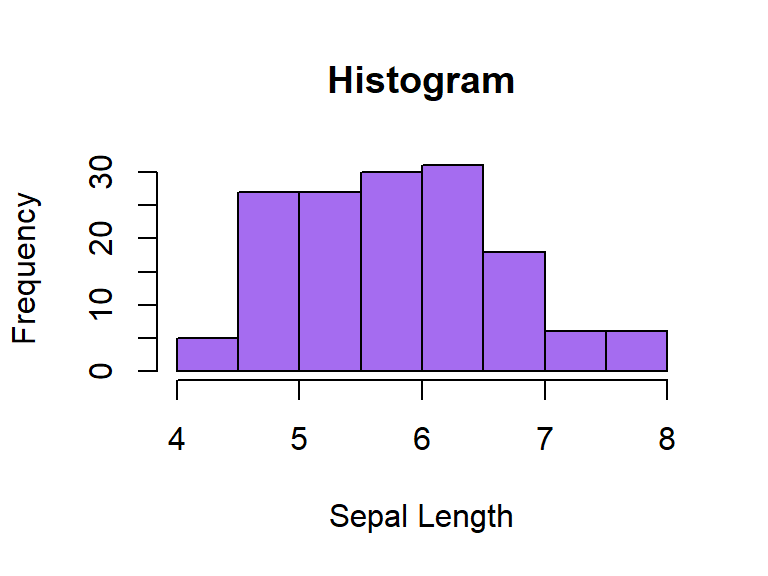

```r
data(iris)

data_vect <- iris$Sepal.Length

hist(data_vect, col="#a56cf0", main="Histogram", xlab="Sepal Length", border="black")
```

#### Barplot

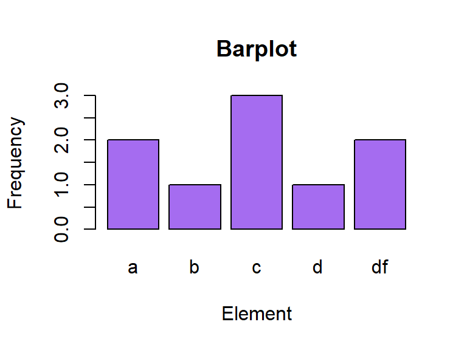

```r
# Use the table() function to first get frequency count. Then plot the results.


str_vector <- c("a","c","df","c","b","a","c","d","df")


barplot(table(str_vector)
        , col="#a56cf0"
        , main="Barplot"
        , xlab="Element"
        , border="black"
        , ylab="Frequency")
```

#### ggplot

##### - Histogram w/Lines

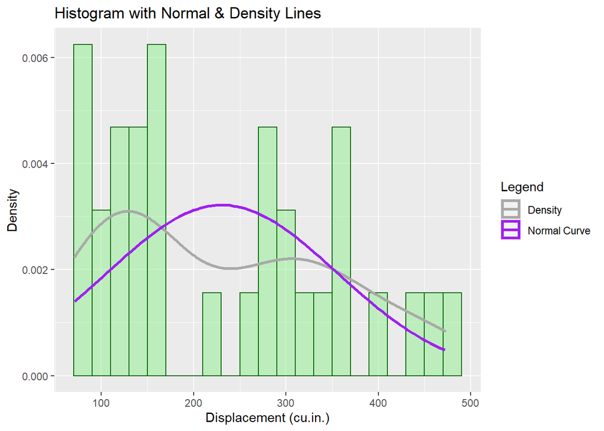

```r
library(ggplot2)

mtcars_df <- mtcars

mtcars_df %>%
  ggplot(
    aes(x=disp)
  ) +
  geom_histogram(mapping = aes(y =..density..)
                 , binwidth = 20
                 , color="darkgreen"
                 , fill="lightgreen"
                 , alpha=0.5) +
  geom_density(size = 1.2, aes(color = "Density")) +
  stat_function(fun = dnorm,
                args = list(mean = mean(mtcars_df$disp, na.rm=TRUE)
                            , sd = sd(mtcars_df$disp, na.rm=TRUE))
                , aes(color = "Normal Curve")
                , size = 1.2
  ) +
  ggtitle("Histogram with Normal & Density Lines") +
  labs(
    x = "Displacement (cu.in.)"
    , y = "Density"
  ) +
  scale_color_manual("Legend", values = c("darkgrey", "purple"))
```

##### - Plot w/Regression

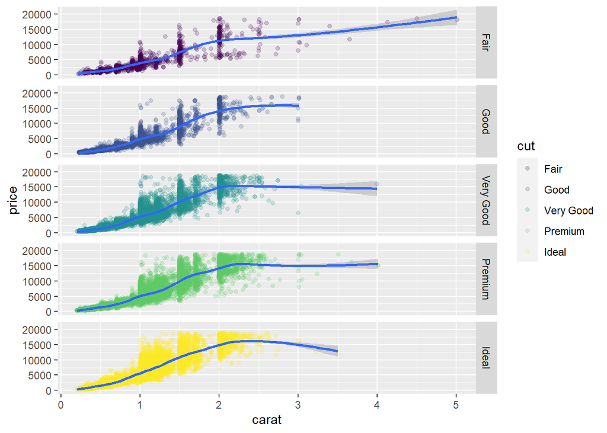

```r
library(ggplot2)

d_df <- diamonds

d_df %>%
  ggplot(
    aes(x=carat, y=price)
  ) +
  facet_grid(rows=vars(cut)) +
  geom_point(aes(col=cut), alpha=.2) +
  geom_smooth()
```

#### Q-Q (quantile-quantile) Plot

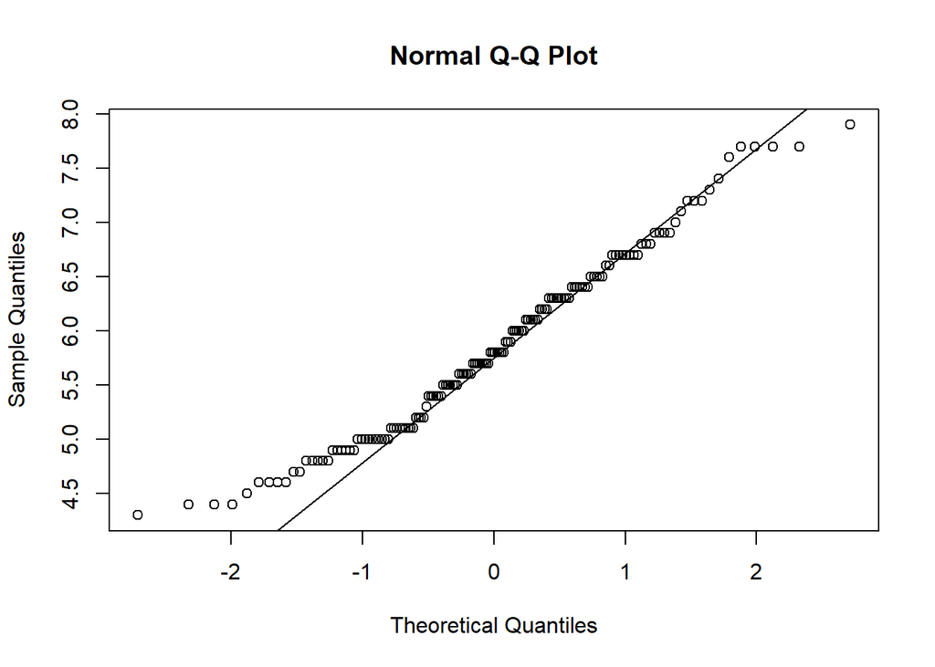

```r
qqnorm(iris$Sepal.Length); qqline(iris$Sepal.Length)
```